# EXP 2 (Kiss, Pieper, Börner 2023)

23.03.2023

### Analysis of experimental study on object-oriented and subject-oriented modifiers

This document provides the analysis for the experimental study on object-oriented and subject-oriented event-internal modifiers with alternating wh-indefinites and full indefinite NPs discussed in Kiss, Pieper, Börner (2023) (EXP 2).

#### Read in required libraries

```r
library(lme4)
library(tidyverse)
library(emmeans)
library(kableExtra)
library(brms)

show(version)
```

```
##                _
## platform       aarch64-apple-darwin20
## arch           aarch64
## os             darwin20
## system         aarch64, darwin20
## status
## major          4
## minor          2.1
## year           2022
## month          06
## day            23
## svn rev        82513
## language       R
## version.string R version 4.2.1 (2022-06-23)
## nickname       Funny-Looking Kid
```

### Read in data

We provide a summary of the data. The test items contained in the data set are pretty-printed below.

```r
data <-
  read.csv("../Data/EXP_2_test.csv",
           fileEncoding = "UTF-8", stringsAsFactors = TRUE) %>%
  mutate(OBJform = relevel(OBJform, ref = "NP"),                    # reference level for OBJform
         subjects = factor(workerId),
         items = factor(ITEM_ID))

## The reference level for TYPE is taken to be COM(O)

summary(subset(data, select = -c(OPTION_0_ITEM, OPTION_1_ITEM, OPTION_0_KEY_CONDITION,
                                 OPTION_1_KEY_CONDITION, date_time_begin, date_time_end,
                                 workerId, ITEM_ID)))
```

```
##  ITEM_FUNCTION ITEM_SUBGROUP      TYPE     OBJform         P       comment
##  test:744      Mode:logical   COM(O):372   NP:372   mit(MOD):372   test:744
##                NA's:744       INSTR :372   wh:372   mittels :186
##                                                     über    :186
##
##
##
##
##     ANSWER    ANSWER_POSITION       rt         trial_index       subjects
##  OBJ>PP:489   above:338       Min.   : 3865   Min.   : 7.00   455    : 24
##  PP>OBJ:255   below:406       1st Qu.: 7563   1st Qu.:18.50   456    : 24
##                               Median : 9838   Median :33.00   457    : 24
##                               Mean   :11008   Mean   :35.03   458    : 24
##                               3rd Qu.:12942   3rd Qu.:51.25   461    : 24
##                               Max.   :38087   Max.   :69.00   463    : 24
##                                                               (Other):600
##      items
##  t01    : 31
##  t02    : 31
##  t03    : 31
##  t04    : 31
##  t05    : 31
##  t06    : 31
##  (Other):558
```

### Test items

The following table provides the 24 minimal pairs of test items used in EXP 2. The experimental data have been judged by 31 participants after filtering unattentive participants according to Pieper et al. (2023).

| Test Item Pair | Adverbial Type | PP > OBJ | OBJ > PP |
| --- | --- | --- | --- |
| t01 | INSTR | Ben hat erzählt, dass ein Geschäftsmann über eine Kreditkarte was abgerechnet hat. Was es war, weiß ich aber nicht. | Ben hat erzählt, dass ein Geschäftsmann was über eine Kreditkarte abgerechnet hat. Was es war, weiß ich aber nicht. |
| t02 | INSTR | Lea hat erzählt, dass ein Veranstaltungstechniker über einen Computer was gesteuert hat. Was es war, weiß ich aber nicht. | Lea hat erzählt, dass ein Veranstaltungstechniker was über einen Computer gesteuert hat. Was es war, weiß ich aber nicht. |
| t03 | INSTR | Max hat erzählt, dass ein Pfleger über eine Pipette was verabreicht hat. Was es war, weiß ich aber nicht. | Max hat erzählt, dass ein Pfleger was über eine Pipette verabreicht hat. Was es war, weiß ich aber nicht. |
| t04 | INSTR | Ich habe gehört, dass ein Wissenschaftler mittels eines Mikroskops was untersucht hat. Was es war, weiß ich aber nicht. | Ich habe gehört, dass ein Wissenschaftler was mittels eines Mikroskops untersucht hat. Was es war, weiß ich aber nicht. |
| t05 | INSTR | Ich habe gehört, dass ein Heimkind mittels eines Feuerzeugs was angezündet hat. Was es war, weiß ich aber nicht. | Ich habe gehört, dass ein Heimkind was mittels eines Feuerzeugs angezündet hat. Was es war, weiß ich aber nicht. |
| t06 | INSTR | Pia hat erzählt, dass ein Industriearbeiter mittels einer Turbine was angetrieben hat. Was es war, weiß ich aber nicht. | Pia hat erzählt, dass ein Industriearbeiter was mittels einer Turbine angetrieben hat. Was es war, weiß ich aber nicht. |
| t07 | INSTR | Ich habe gehört, dass ein Angestellter über einen Grafikeditor ein Schnittmuster erstellt hat. Was für eins es war, weiß ich aber nicht. | Ich habe gehört, dass ein Angestellter ein Schnittmuster über einen Grafikeditor erstellt hat. Was für eins es war, weiß ich aber nicht. |
| t08 | INSTR | Ich habe gehört, dass ein Busfahrer über ein Mikrofon einen Haltestellenausfall angekündigt hat. Welche Busstation betroffen war, weiß ich aber nicht. | Ich habe gehört, dass ein Busfahrer einen Haltestellenausfall über ein Mikrofon angekündigt hat. Welche Busstation betroffen war, weiß ich aber nicht. |
| t09 | INSTR | Ich habe gehört, dass ein Schüler über eine Tastatur ein Notebook bedient hat. Was er genau gemacht hat, weiß ich aber nicht. | Ich habe gehört, dass ein Schüler ein Notebook über eine Tastatur bedient hat. Was er genau gemacht hat, weiß ich aber nicht. |
| t10 | INSTR | Eva hat erzählt, dass ein Mediziner mittels einer Spritze eine Substanz injiziert hat. Was er genau gespritzt hat, weiß ich aber nicht. | Eva hat erzählt, dass ein Mediziner eine Substanz mittels einer Spritze injiziert hat. Was er genau gespritzt hat, weiß ich aber nicht. |
| t11 | INSTR | Ich habe gehört, dass ein Fußballer mittels eines Attests eine Verletzung nachgewiesen hat. Was er genau hatte, weiß ich aber nicht. | Ich habe gehört, dass ein Fußballer eine Verletzung mittels eines Attests nachgewiesen hat. Was er genau hatte, weiß ich aber nicht. |
| t12 | INSTR | Jan hat erzählt, dass ein Truppenführer mittels eines Mobiltelefons einen Befehl übermittelt hat. Was für einen, weiß ich aber nicht. | Jan hat erzählt, dass ein Truppenführer einen Befehl mittels eines Mobiltelefons übermittelt hat. Was für einen, weiß ich aber nicht. |
| t13 | COM(O) | Lea hat erzählt, dass ein Kleinkrimineller zusammen mit einer Stichwaffe was vergraben hat. Was es war, weiß ich aber nicht. | Lea hat erzählt, dass ein Kleinkrimineller was zusammen mit einer Stichwaffe vergraben hat. Was es war, weiß ich aber nicht. |
| t14 | COM(O) | Ich habe gehört, dass eine Schuldirektorin zusammen mit einer Einladung was verschickt hat. Was es war, weiß ich aber nicht. | Ich habe gehört, dass eine Schuldirektorin was zusammen mit einer Einladung verschickt hat. Was es war, weiß ich aber nicht. |
| t15 | COM(O) | Ich habe gehört, dass ein Abgeordneter zusammen mit einem Finanzplan was vorgelegt hat. Was es war, weiß ich aber nicht. | Ich habe gehört, dass ein Abgeordneter was zusammen mit einem Finanzplan vorgelegt hat. Was es war, weiß ich aber nicht. |
| t16 | COM(O) | Jan hat erzählt, dass ein Lokaljournalist zusammen mit einem Foto was veröffentlicht hat. Was es war, weiß ich aber nicht. | Jan hat erzählt, dass ein Lokaljournalist was zusammen mit einem Foto veröffentlicht hat. Was es war, weiß ich aber nicht. |
| t17 | COM(O) | Tim hat erzählt, dass eine Haushälterin zusammen mit einem Handtuch was gewaschen hat. Was es war, weiß ich aber nicht. | Tim hat erzählt, dass eine Haushälterin was zusammen mit einem Handtuch gewaschen hat. Was es war, weiß ich aber nicht. |
| t18 | COM(O) | Ich habe gehört, dass ein Kurator zusammen mit einem Preisgeld was verliehen hat. Was es war, weiß ich aber nicht. | Ich habe gehört, dass ein Kurator was zusammen mit einem Preisgeld verliehen hat. Was es war, weiß ich aber nicht. |
| t19 | COM(O) | Ich habe gehört, dass eine Küchenhilfe zusammen mit einem Schnitzel einen Krapfen angebraten hat. Warum sie das getan hat, weiß ich aber nicht. | Ich habe gehört, dass eine Küchenhilfe einen Krapfen zusammen mit einem Schnitzel angebraten hat. Warum sie das getan hat, weiß ich aber nicht. |
| t20 | COM(O) | Pia hat erzählt, dass ein Tierschützer zusammen mit einem Überweisungsträger eine Broschüre versandt hat. Was für eine, weiß ich aber nicht. | Pia hat erzählt, dass ein Tierschützer eine Broschüre zusammen mit einem Überweisungsträger versandt hat. Was für eine, weiß ich aber nicht. |
| t21 | COM(O) | Ich habe gehört, dass ein Minister zusammen mit einer Urkunde einen Orden überreicht hat. Was für einen, weiß ich aber nicht. | Ich habe gehört, dass ein Minister einen Orden zusammen mit einer Urkunde überreicht hat. Was für einen, weiß ich aber nicht. |
| t22 | COM(O) | Kai hat erzählt, dass ein Antiquitätenhändler zusammen mit einem Gemälde eine Statue verkauft hat. Was für eine, weiß ich aber nicht. | Kai hat erzählt, dass ein Antiquitätenhändler eine Statue zusammen mit einem Gemälde verkauft hat. Was für eine, weiß ich aber nicht. |
| t23 | COM(O) | Eva hat erzählt, dass ein Kellner zusammen mit einer Süßspeise ein Heißgetränk serviert hat. Was für eins, weiß ich aber nicht. | Eva hat erzählt, dass ein Kellner ein Heißgetränk zusammen mit einer Süßspeise serviert hat. Was für eins, weiß ich aber nicht. |
| t24 | COM(O) | Ich habe gehört, dass ein Hobbykoch zusammen mit einer Knoblauchzehe eine Chilischote püriert hat. Wofür genau, weiß ich aber nicht. | Ich habe gehört, dass ein Hobbykoch eine Chilischote zusammen mit einer Knoblauchzehe püriert hat. Wofür genau, weiß ich aber nicht. |

#### Empirical distribution of choices

The following plot shows the distribution of empirical choices of the serializations (`PP > OBJ`, `OBJ > PP`) across the two different forms of the object (`Full NP indefinite`, `wh-indefinite`).

We observe a difference in distribution between full indefinite NPs and wh-indefinites insofar as the distribution of the latter is similar across types, while the former shows clear differences between `INSTR` and `COM(O)`. Regarding the research question, it is of particular interest that the number of `OBJ > PP` serializations for `INSTR` is higher for `wh-indefinites` than for `full indefinite NPs`. A theoretical analysis relying on scrambling would have assumed that `OBJ > PP` could not occur with wh-indefinites, given a base position of the adverbial above the object.

```r
summary <-
  data %>%
  group_by(TYPE, OBJform, ANSWER) %>%
  summarise(count=n())

summary
```

```
## # A tibble: 8 × 4
## # Groups:   TYPE, OBJform [4]
##   TYPE   OBJform ANSWER count
##   <fct>  <fct>   <fct>  <int>
## 1 COM(O) NP      OBJ>PP   148
## 2 COM(O) NP      PP>OBJ    38
## 3 COM(O) wh      OBJ>PP   116
## 4 COM(O) wh      PP>OBJ    70
## 5 INSTR  NP      OBJ>PP   105
## 6 INSTR  NP      PP>OBJ    81
## 7 INSTR  wh      OBJ>PP   120
## 8 INSTR  wh      PP>OBJ    66
```

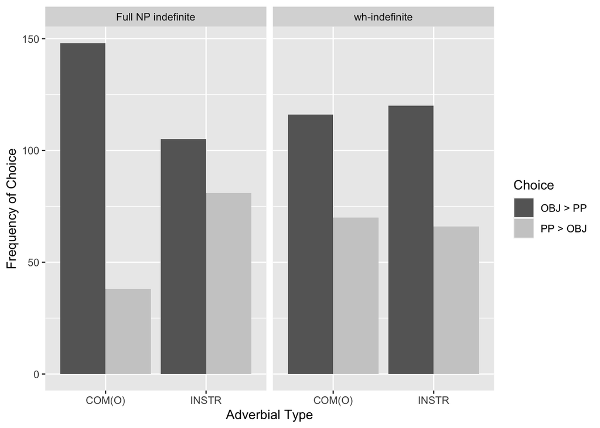

```r
form.labels <- c("Full NP indefinite", "wh-indefinite")
names(form.labels) <- c("NP", "wh")


ggplot(summary, aes(x = TYPE, y = count, fill = ANSWER)) +
  geom_bar(stat = "identity", position = "dodge") +
  labs(x = "Adverbial Type", y = "Frequency of Choice") +
  scale_fill_manual(name = "Choice", values = c("OBJ>PP" = "grey40","PP>OBJ" = "grey80"),
                    labels = c("OBJ > PP", "PP > OBJ")) +
  facet_wrap(~OBJform, labeller = labeller(OBJform = form.labels))
```

### Random slope model

In the following, we define a random slope model (random slopes for the interaction of both predictors) for participants, and a random intercept model for items (which do not vary across conditions). Please notice that the random structure for subjects does not assume intercepts, because we want to obtain information on by-subject variance for each condition. To avoid a possibly spurious convergence warning for the model, we use a wrapper to access a non-linear optimizer from the library `nloptr`. For a general assessment of possibly spurious convergence warning see https://rstudio-pubs-static.s3.amazonaws.com/33653_57fc7b8e5d484c909b615d8633c01d51.html and particularly https://joshua-nugent.github.io/allFit/.

```r
model <- glmer(ANSWER ~ TYPE * OBJform +
                 (0 + TYPE * OBJform | subjects) + (1 | items),
               data = data, family = "binomial",
               control=glmerControl(
                 optimizer = "nloptwrap",
                 optCtrl = list(algorithm = "NLOPT_LN_NELDERMEAD")))

summary(model)
```

```
## Generalized linear mixed model fit by maximum likelihood (Laplace
##   Approximation) [glmerMod]
##  Family: binomial  ( logit )
## Formula: ANSWER ~ TYPE * OBJform + (0 + TYPE * OBJform | subjects) + (1 |
##     items)
##    Data: data
## Control:
## glmerControl(optimizer = "nloptwrap", optCtrl = list(algorithm = "NLOPT_LN_NELDERMEAD"))
##
##      AIC      BIC   logLik deviance df.resid
##    875.3    944.5   -422.7    845.3      729
##
## Scaled residuals:
##     Min      1Q  Median      3Q     Max
## -1.8407 -0.6322 -0.3518  0.7466  2.8947
##
## Random effects:
##  Groups   Name                Variance Std.Dev. Corr
##  subjects TYPECOM(O)          1.7227   1.3125
##           TYPEINSTR           0.8774   0.9367    0.40
##           OBJformwh           1.0426   1.0211    0.28  0.71
##           TYPEINSTR:OBJformwh 1.8958   1.3769   -0.05 -0.63 -0.97
##  items    (Intercept)         0.2884   0.5371
## Number of obs: 744, groups:  subjects, 31; items, 24
##
## Fixed effects:
##                     Estimate Std. Error z value Pr(>|z|)
## (Intercept)          -1.8128     0.4072  -4.452 8.52e-06 ***
## TYPEINSTR             1.5002     0.4872   3.079  0.00208 **
## OBJformwh             1.0292     0.4797   2.146  0.03190 *
## TYPEINSTR:OBJformwh  -1.4654     0.6425  -2.281  0.02256 *
## ---
## Signif. codes:  0 '***' 0.001 '**' 0.01 '*' 0.05 '.' 0.1 ' ' 1
##
## Correlation of Fixed Effects:
##             (Intr) TYPEINSTR OBJfrm
## TYPEINSTR   -0.756
## OBJformwh   -0.493  0.507
## TYPEINSTR:O  0.405 -0.661    -0.782
```

We notice that all coefficients show significant effects. It is not particularly surprising that `COM(O)` strongly prefers `OBJ > PP`. In the following, we use `emmeans` to calculate the model predictions, which are also printed together with their 95 % CIs.

```r
results <- emmeans(model, pairwise~OBJform * TYPE , type = "response")

results$emmeans
```

```
##  OBJform TYPE    prob     SE  df asymp.LCL asymp.UCL
##  NP      COM(O) 0.140 0.0491 Inf    0.0684     0.266
##  wh      COM(O) 0.314 0.0971 Inf    0.1588     0.525
##  NP      INSTR  0.422 0.0783 Inf    0.2805     0.578
##  wh      INSTR  0.321 0.0709 Inf    0.1999     0.472
##
## Confidence level used: 0.95
## Intervals are back-transformed from the logit scale
```

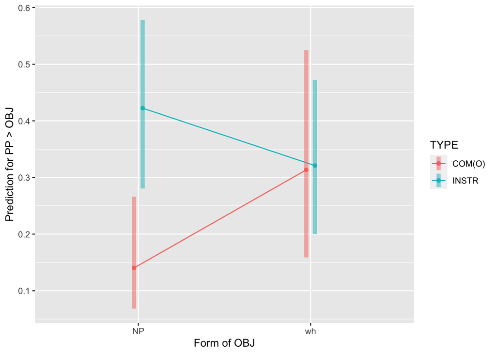

```r
emmip(model, TYPE ~ OBJform, type = "response", CIs = TRUE,
      xlab = "Form of OBJ", ylab = "Prediction for PP > OBJ")
```

```r
ggsave("../Figures/EXP_2.preds.pdf")
```

In the following, we compare the model with interactions to a model with the same random structure, but without interactions. The difference between the two models is significant.

```r
model_2 <- glmer(ANSWER ~ TYPE + OBJform +
                     (0 + TYPE * OBJform | workerId) +
                     (1|ITEM_ID), data = data, family = "binomial",
                   control=glmerControl(optimizer = "nloptwrap",
                                        optCtrl = list(algorithm = "NLOPT_LN_NELDERMEAD")))

anova(model_2, model, test = "Chisq")
```

```
## Data: data
## Models:
## model_2: ANSWER ~ TYPE + OBJform + (0 + TYPE * OBJform | workerId) + (1 | ITEM_ID)
## model: ANSWER ~ TYPE * OBJform + (0 + TYPE * OBJform | subjects) + (1 | items)
##         npar    AIC    BIC  logLik deviance  Chisq Df Pr(>Chisq)
## model_2   14 877.99 942.55 -424.99   849.99
## model     15 875.32 944.50 -422.66   845.32 4.6679  1    0.03073 *
## ---
## Signif. codes:  0 '***' 0.001 '**' 0.01 '*' 0.05 '.' 0.1 ' ' 1
```

The following Bayesian model is included to provide more information about the likelihood distribution of the predictors. We have included a calculation of the region of practical equivalence (ROPE). For three of the four coefficients, it can be rejected that they do not show an effect (`COM(O)/NP`, `INSTR/NP`, `INSTR/wh`).

We notice the warning, but it is unclear whether we should consider it or not, see: https://github.com/easystats/bayestestR/discussions/555 and https://easystats.github.io/bayestestR/reference/rope.html.

```r
bayes_model <- brm(ANSWER ~ TYPE * OBJform + (0 + TYPE * OBJform | subjects) + (1|items),
                   data = data,
                   bernoulli(link = "logit"),
                   warmup = 1000,
                   iter = 4000,
                   chains = 4,
                   control = list(adapt_delta = 0.99),
                   cores = parallel::detectCores())
bayes_model
```

```
##  Family: bernoulli
##   Links: mu = logit
## Formula: ANSWER ~ TYPE * OBJform + (0 + TYPE * OBJform | subjects) + (1 | items)
##    Data: data (Number of observations: 744)
##   Draws: 4 chains, each with iter = 4000; warmup = 1000; thin = 1;
##          total post-warmup draws = 12000
##
## Group-Level Effects:
## ~items (Number of levels: 24)
##               Estimate Est.Error l-95% CI u-95% CI Rhat Bulk_ESS Tail_ESS
## sd(Intercept)     0.68      0.18     0.38     1.07 1.00     4568     7717
##
## ~subjects (Number of levels: 31)
##                                    Estimate Est.Error l-95% CI u-95% CI Rhat
## sd(TYPECOMO)                           1.58      0.37     0.96     2.38 1.00
## sd(TYPEINSTR)                          0.95      0.26     0.49     1.52 1.00
## sd(OBJformwh)                          0.55      0.38     0.03     1.42 1.00
## sd(TYPEINSTR:OBJformwh)                0.63      0.46     0.03     1.73 1.00
## cor(TYPECOMO,TYPEINSTR)                0.44      0.23    -0.07     0.83 1.00
## cor(TYPECOMO,OBJformwh)                0.19      0.39    -0.61     0.84 1.00
## cor(TYPEINSTR,OBJformwh)               0.21      0.40    -0.63     0.86 1.00
## cor(TYPECOMO,TYPEINSTR:OBJformwh)      0.02      0.40    -0.76     0.76 1.00
## cor(TYPEINSTR,TYPEINSTR:OBJformwh)    -0.14      0.42    -0.84     0.73 1.00
## cor(OBJformwh,TYPEINSTR:OBJformwh)    -0.25      0.46    -0.92     0.71 1.00
##                                    Bulk_ESS Tail_ESS
## sd(TYPECOMO)                           4450     7182
## sd(TYPEINSTR)                          5915     6195
## sd(OBJformwh)                          2255     4130
## sd(TYPEINSTR:OBJformwh)                2069     4454
## cor(TYPECOMO,TYPEINSTR)                4274     7049
## cor(TYPECOMO,OBJformwh)                8619     7792
## cor(TYPEINSTR,OBJformwh)               6190     8035
## cor(TYPECOMO,TYPEINSTR:OBJformwh)      9441     7624
## cor(TYPEINSTR,TYPEINSTR:OBJformwh)     7433     8386
## cor(OBJformwh,TYPEINSTR:OBJformwh)     3981     7595
##
## Population-Level Effects:
##                     Estimate Est.Error l-95% CI u-95% CI Rhat Bulk_ESS Tail_ESS
## Intercept              -1.88      0.49    -2.87    -0.96 1.00     3049     4792
## TYPEINSTR               1.58      0.58     0.47     2.74 1.00     3388     5347
## OBJformwh               1.14      0.53     0.10     2.20 1.00     3728     5373
## TYPEINSTR:OBJformwh    -1.64      0.71    -3.07    -0.25 1.00     3477     5520
##
## Draws were sampled using sampling(NUTS). For each parameter, Bulk_ESS
## and Tail_ESS are effective sample size measures, and Rhat is the potential
## scale reduction factor on split chains (at convergence, Rhat = 1).
```

```r
bayestestR::equivalence_test(bayes_model)
```

```
## Possible multicollinearity between b_TYPEINSTR:OBJformwh and b_OBJformwh (r = 0.71). This might lead to inappropriate results. See 'Details' in '?equivalence_test'.
```

```
## # Test for Practical Equivalence
##
##   ROPE: [-0.18 0.18]
##
## Parameter           |        H0 | inside ROPE |       95% HDI
## -------------------------------------------------------------
## Intercept           |  Rejected |      0.00 % | [-2.87 -0.96]
## TYPEINSTR           |  Rejected |      0.00 % | [ 0.47  2.74]
## OBJformwh           | Undecided |      0.82 % | [ 0.10  2.20]
## TYPEINSTR:OBJformwh |  Rejected |      0.00 % | [-3.07 -0.25]
```

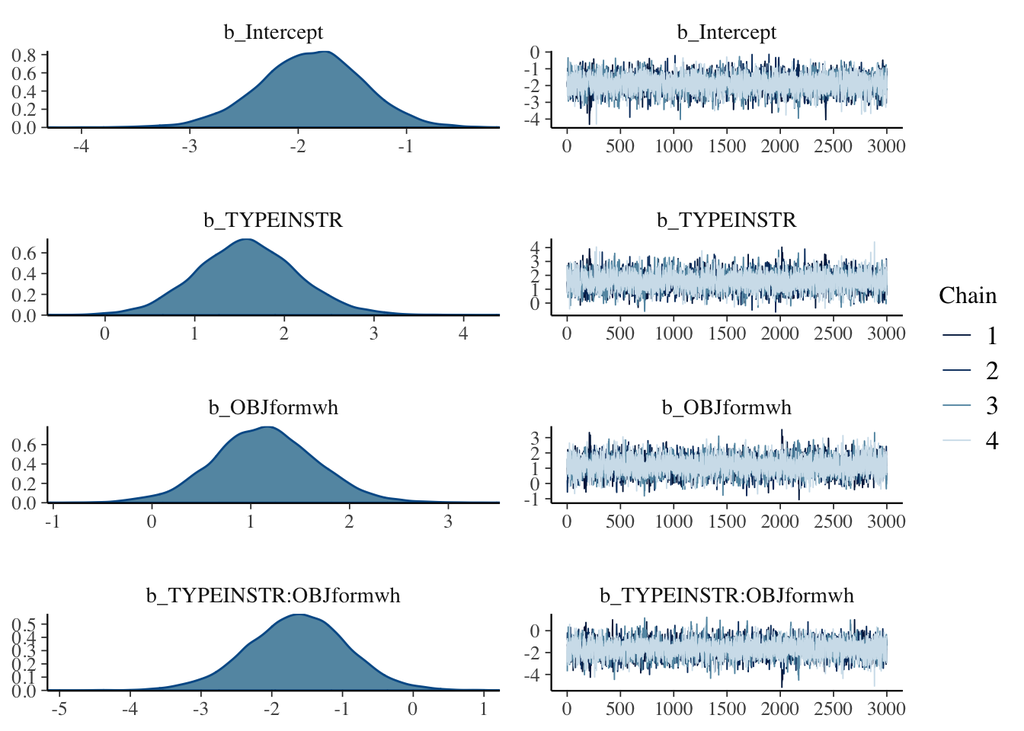

```r
plot(bayes_model, variable = "^b_", regex = TRUE)
```

```r
ggsave("../Figures/EXP_2.bayes.pdf")
```